# Stat 585 - Working in teams: Sample solution for the test case

Heike Hofmann

# Sample Solution to the test case

## A test case

We are asked to :

1. Visualize life expectancy over time for Canada in the 1950s and 1960s using a line plot.
2. Something is clearly wrong with this plot! Turns out there’s a data error in the data file: life expectancy for Canada in the year 1957 is coded as `999999`, it should actually be `69.96`. Make this correction.
3. Visualize life expectancy over time for Canada again, with the corrected data.

Using the gapminder data provided

## Step-by-step plan of work

1. Read the data
2. Focus on values of Canada
3. Visualize the values for Canada
4. See whether we can find the problem
5. … then we’ll see …

## Reading the data

```r
life5060 <- read.csv("data/gapminder-5060.csv")
head(life5060)
```

```
##       country continent year lifeExp      pop gdpPercap
## 1 Afghanistan      Asia 1952  28.801  8425333  779.4453
## 2 Afghanistan      Asia 1957  30.332  9240934  820.8530
## 3 Afghanistan      Asia 1962  31.997 10267083  853.1007
## 4 Afghanistan      Asia 1967  34.020 11537966  836.1971
## 5     Albania    Europe 1952  55.230  1282697 1601.0561
## 6     Albania    Europe 1957  59.280  1476505 1942.2842
```

## Focus on the values for Canada

```r
canada <- life5060 %>% filter(country == "Canada")
head(canada)
```

```
##   country continent year   lifeExp      pop gdpPercap
## 1  Canada  Americas 1952     68.75 14785584  11367.16
## 2  Canada  Americas 1957 999999.00 17010154  12489.95
## 3  Canada  Americas 1962     71.30 18985849  13462.49
## 4  Canada  Americas 1967     72.13 20819767  16076.59
```

## Visualize

Draw a line for the life expectancy in Canada

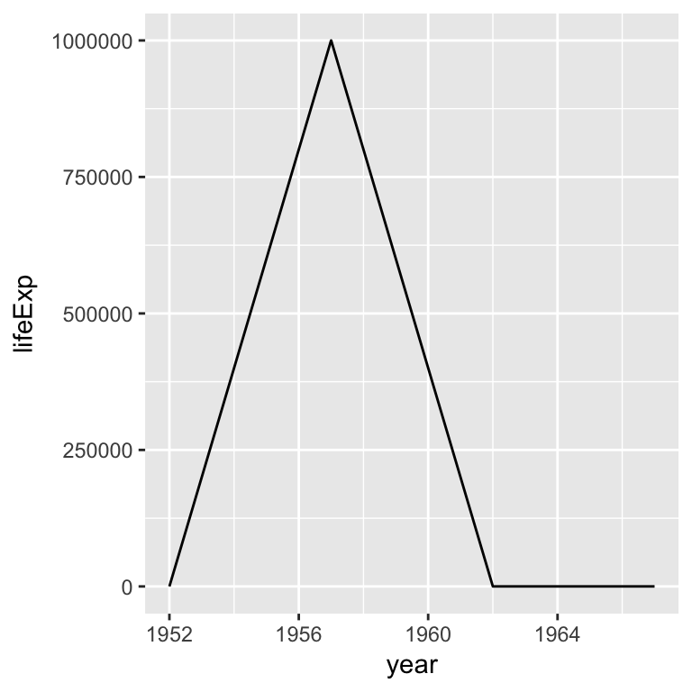

```r
canada %>%
  ggplot(aes(x = year, y = lifeExp)) +
  geom_line()
```

## Find the problematic value and fix it

```r
canada %>% filter(year == 1957)
```

```
##   country continent year lifeExp      pop gdpPercap
## 1  Canada  Americas 1957  999999 17010154  12489.95
```

```r
canada_fixed <- canada %>% mutate(
  lifeExp = replace(lifeExp, year==1957, 69.96)
)
```

## visualize the fixed data

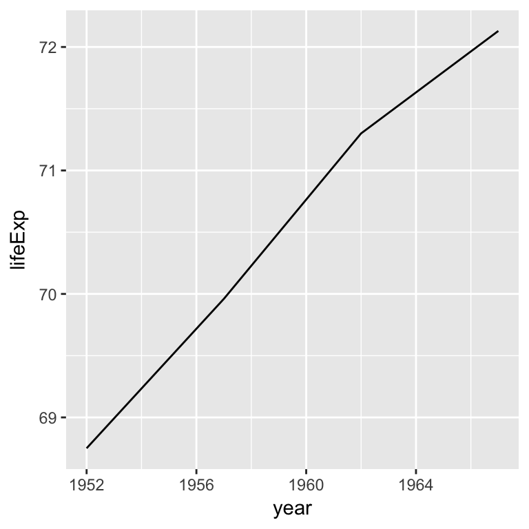

```r
canada_fixed %>% ggplot(aes(x = year, y = lifeExp)) +
  geom_line()
```

## … on to the stretch goal …

Add lines for Mexico and the US

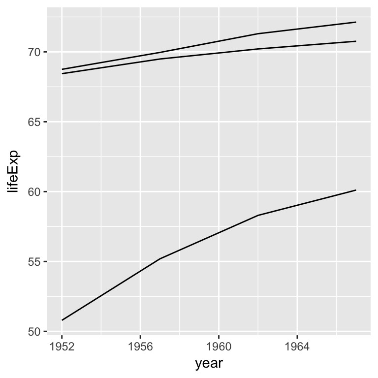

```r
canada_fixed %>%
  ggplot(aes(x = year, y = lifeExp, group=country)) + geom_line() +
  geom_line(data = life5060 %>%
              filter(country %in% c("United States", "Mexico")))
```

## … on to the stretch goal …

Add lines for Mexico and the US, color lines by country and add a legend

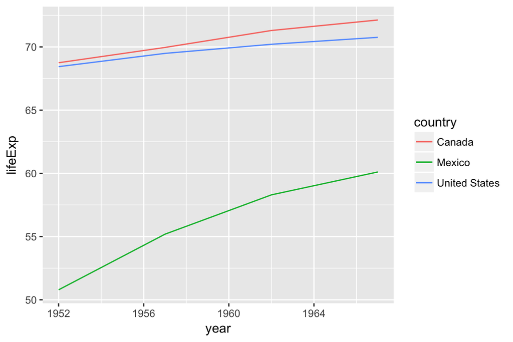

```r
canada_fixed %>%
  ggplot(aes(x = year, y = lifeExp, colour=country)) + geom_line() +
  geom_line(data = life5060 %>%
              filter(country %in% c("United States", "Mexico")))
```

## How reproducible is this solution?

1. Navigate to https://github.com/stat480-at-isu/materials
2. Open the folder `01_collaborative-environment` and download the file `02_test-case-solution.Rmd`
3. Open the file in RStudio.
4. “Knit” the file.

## R Markdown

- code and text/documentation are interwoven: reproducible and self-documenting.
- extend or refine analyses by copying and modifying code blocks.
- disseminate your work by sharing the RMarkdown file